# DA_hw05

Lin,Pei Chen

2023-03-29

Q1.

```r
library(png)
library(glmnet)
```

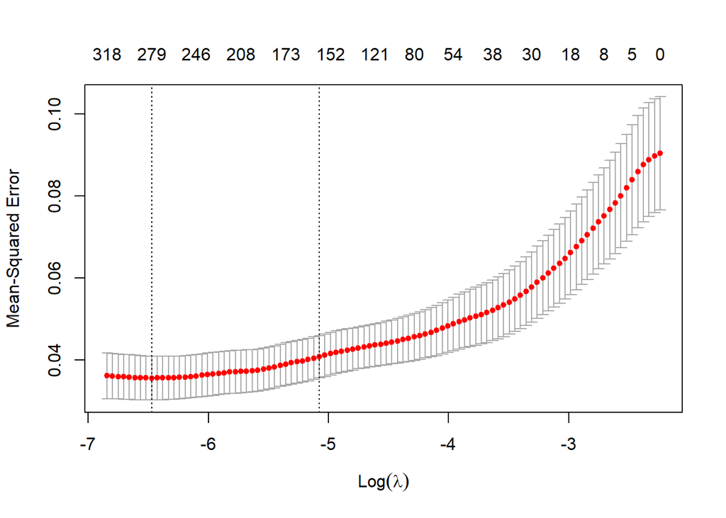

```r
path <- "C:/Users/simpl/OneDrive/桌面/111_下學期/資料分析方法/HW02/ORL Faces/ORL Faces"

data <- data.frame(matrix(nrow = 0, ncol = 2576),row.names = character())

for (i in 1:40) {
  for(j in 1:10){
    file <- file.path(path, paste0( i,"_",j,".png"))
    img <- readPNG(file)
    vec <- as.vector(img)
    data <- rbind(data, vec)
  }
}
gender<-c(rep(0,10),rep(1,10),rep(1,10),rep(1,10),rep(1,10),rep(1,10),rep(1,10),rep(0,10),rep(1,10),rep(0,10),
          rep(1,10),rep(1,10),rep(1,10),rep(1,10),rep(1,10),rep(1,10),rep(1,10),rep(1,10),rep(1,10),rep(1,10),
          rep(1,10),rep(1,10),rep(1,10),rep(1,10),rep(1,10),rep(1,10),rep(1,10),rep(1,10),rep(1,10),rep(1,10),
          rep(1,10),rep(0,10),rep(1,10),rep(1,10),rep(1,10),rep(1,10),rep(1,10),rep(1,10),rep(1,10),rep(1,10))
names(data) <- paste0("Pixel", 1:2576)


data<-as.matrix(data)
gender<-as.matrix(gender)
cv_model <- cv.glmnet(data,gender,alpha=1)
best_lambda <- cv_model$lambda.min
plot(cv_model)
```

```r
lasso_model <- glmnet(data,gender,alpha = 1,lambda = best_lambda)
coef<-coef(lasso_model)
```

```r
coef(lasso_model)
```

```
## 2577 x 1 sparse Matrix of class "dgCMatrix"
##                        s0
## (Intercept)  9.594111e-01
## Pixel1       .
## Pixel2       .
## Pixel3       .
## Pixel4       .
## Pixel5       .
## Pixel6       .
## Pixel7       .
## Pixel8       .
## Pixel9       .
## Pixel10      .
## Pixel11      .
## Pixel12      .
## Pixel13      8.827208e-02
## Pixel14      .
## Pixel15     -9.114784e-02
## Pixel16      .
## Pixel17      .
## Pixel18     -2.749304e-02
## Pixel19      .
## Pixel20      .
## Pixel21      .
## Pixel22      .
## Pixel23      .
## Pixel24      .
## Pixel25      .
## Pixel26      .
## Pixel27      .
## Pixel28      .
## Pixel29      .
## Pixel30      .
## Pixel31      .
## Pixel32      .
## Pixel33      6.137859e-02
## Pixel34      .
## Pixel35      2.338564e-01
## Pixel36      .
## Pixel37      .
```

[output cut: 2524 more lines]

```
## Pixel2562    .
## Pixel2563    .
## Pixel2564    .
## Pixel2565    .
## Pixel2566    .
## Pixel2567   -3.432432e-02
## Pixel2568   -2.134485e-02
## Pixel2569   -2.538933e-02
## Pixel2570    .
## Pixel2571    .
## Pixel2572    .
## Pixel2573    .
## Pixel2574    .
## Pixel2575    .
## Pixel2576    .
```

```r
ridge_model <- glmnet(data,gender,alpha = 0,lambda = best_lambda)
coef(ridge_model)
```

```
## 2577 x 1 sparse Matrix of class "dgCMatrix"
##                        s0
## (Intercept)  1.036864e+00
## Pixel1       6.185432e-02
## Pixel2       3.290656e-02
## Pixel3       2.616280e-04
## Pixel4      -1.867326e-02
## Pixel5       1.059792e-02
## Pixel6       3.875969e-02
## Pixel7       1.486651e-03
## Pixel8       2.584555e-02
## Pixel9      -2.682980e-02
## Pixel10     -1.541732e-02
## Pixel11      2.575496e-02
## Pixel12      4.155721e-02
## Pixel13      6.501824e-02
## Pixel14      1.346748e-02
## Pixel15     -7.019061e-02
## Pixel16     -6.438977e-02
## Pixel17      2.564757e-02
## Pixel18     -3.180242e-02
## Pixel19     -4.173814e-02
## Pixel20      5.238049e-02
## Pixel21      4.198127e-02
## Pixel22      1.751411e-02
## Pixel23      7.865628e-02
## Pixel24      1.148505e-01
## Pixel25      1.001509e-01
## Pixel26      4.289590e-02
## Pixel27     -2.010879e-02
## Pixel28     -1.489017e-02
## Pixel29      4.126653e-02
## Pixel30      3.760638e-02
## Pixel31     -2.389003e-02
## Pixel32      2.920654e-03
## Pixel33      6.888610e-02
## Pixel34      8.596937e-02
## Pixel35      1.300988e-01
## Pixel36      8.544451e-02
## Pixel37      4.665977e-02
```

[output cut: 2524 more lines]

```
## Pixel2562    1.021495e-01
## Pixel2563    5.690542e-02
## Pixel2564    3.114276e-02
## Pixel2565    6.482908e-03
## Pixel2566   -5.193065e-02
## Pixel2567   -7.153515e-02
## Pixel2568   -7.346413e-02
## Pixel2569   -4.333821e-02
## Pixel2570    3.865075e-02
## Pixel2571    4.378776e-02
## Pixel2572    9.552281e-05
## Pixel2573    8.272523e-03
## Pixel2574   -4.938778e-03
## Pixel2575    6.073920e-03
## Pixel2576    1.022820e-02
```

We can see that the lasso model sets many variable coefficients to zero, which means that many variables are deleted, and only the variables that have strong explanatory power for the predictive variable are retained.

In contrast to the lasso model, the ridge model shrinks the coefficients of all variables towards zero, including those with weaker explanatory power for the predictive variable, but none of them are completely eliminated. Therefore, all variables still contribute to the prediction to some extent, but those with stronger explanatory power have larger coefficients than those with weaker explanatory power.

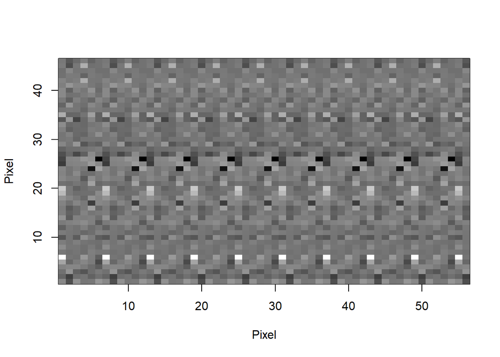

```r
chosen_pixels<-c()
for (i in 1:nrow(coef)){
  if (coef[i, ] != 0){
    x<-coef[i,]
    chosen_pixels<-rbind(chosen_pixels,x)
  }
}
chosen_pixels <- chosen_pixels[-1]
chosen_pixels[is.na(chosen_pixels)] <- 0
chosen_pixels_array <- array(chosen_pixels, dim = c(46, 56))
image(1:56, 1:46, t(chosen_pixels_array), col = gray(seq(0, 1, length = 256)), xlab = "Pixel", ylab = "Pixel")
```

Q2. a.

```r
data <- data.frame(
  year = c(72:86),
  capital = c(1209188, 1330372, 1157371, 1070860, 1233475, 1355769, 1351667, 1326248, 1089545, 1111942, 988165, 1069651, 1191677, 1246536, 1281262),
  labor = c(1259142, 1371795, 1263084, 1118226, 1274345, 1369877, 1451595, 1328683, 1077207, 1056231, 947502, 1057159, 1169442, 1195255, 1171664),
  value_added = c(11150.0, 12853.6, 10450.8, 9318.3, 12097.7, 12844.8, 13309.9, 13402.3, 8571.0, 8739.7, 8140.0, 10958.4, 10838.9, 10030.5, 10836.5)
)

model <- lm(log(value_added) ~ log(capital) + log(labor), data = data)
summary(model)
```

```
##
## Call:
## lm(formula = log(value_added) ~ log(capital) + log(labor), data = data)
##
## Residuals:
##       Min        1Q    Median        3Q       Max
## -0.090518 -0.043559 -0.009005  0.022608  0.180405
##
## Coefficients:
##              Estimate Std. Error t value Pr(>|t|)
## (Intercept)   -9.6259     2.8996  -3.320  0.00611 **
## log(capital)   0.5057     0.5061   0.999  0.33743
## log(labor)     0.8455     0.4216   2.006  0.06799 .
## ---
## Signif. codes:  0 '***' 0.001 '**' 0.01 '*' 0.05 '.' 0.1 ' ' 1
##
## Residual standard error: 0.07495 on 12 degrees of freedom
## Multiple R-squared:  0.8184, Adjusted R-squared:  0.7881
## F-statistic: 27.03 on 2 and 12 DF,  p-value: 3.591e-05
```

```r
cat("beta1=",coef(model)[2])
```

```
## beta1= 0.5056509
```

```r
cat("beta2=",coef(model)[3])
```

```
## beta2= 0.8454644
```

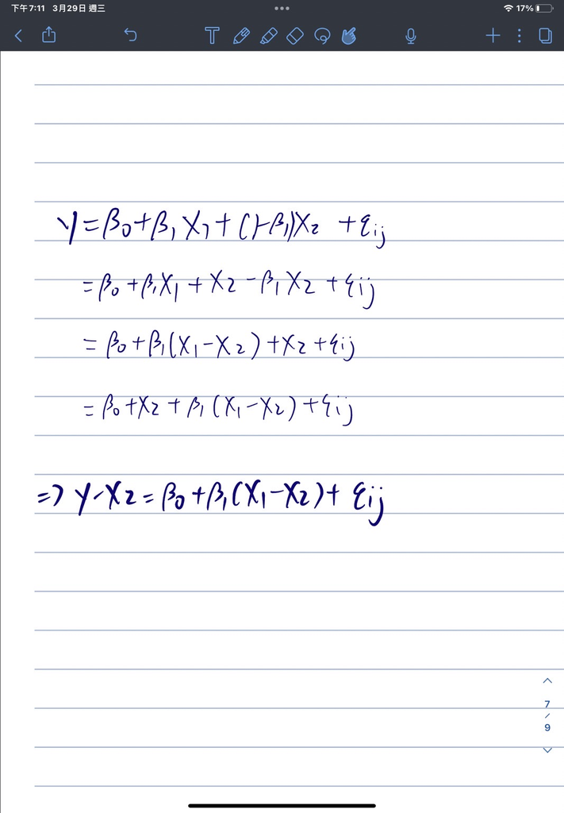

```r
data_log <- log(data)
model<-lm((data_log$value_added- data_log$labor)~(data_log$capital-data_log$labor))
summary(model)
```

```
##
## Call:
## lm(formula = (data_log$value_added - data_log$labor) ~ (data_log$capital -
##     data_log$labor))
##
## Residuals:
##       Min        1Q    Median        3Q       Max
## -0.089662 -0.047484  0.001155  0.026344  0.181032
##
## Coefficients:
##                  Estimate Std. Error t value Pr(>|t|)
## (Intercept)       -9.4108     2.7434  -3.430  0.00447 **
## data_log$capital   0.3357     0.1960   1.712  0.11055
## ---
## Signif. codes:  0 '***' 0.001 '**' 0.01 '*' 0.05 '.' 0.1 ' ' 1
##
## Residual standard error: 0.07242 on 13 degrees of freedom
## Multiple R-squared:  0.1841, Adjusted R-squared:  0.1213
## F-statistic: 2.932 on 1 and 13 DF,  p-value: 0.1105
```

```r
beta1<-coef(model)[2]
beta2<-1-beta1
cat("beta1=",beta1)
```

```
## beta1= 0.3357035
```

```r
cat("beta2=",beta2)
```

```
## beta2= 0.6642965
```

Q3.

```r
PCA <- function(x,isCorrMX=FALSE){
  x<-as.matrix(x)
  n<-nrow(x)
  means<-colMeans(x[1:nrow(x),1:ncol(x)])
  mean<-c()
  for(i in 1:ncol(x)){
    mean<-cbind(mean,rep(means[i],nrow(x)))
  }
  A<-as.matrix(x-mean)
  cov<-t(A)%*%A/(n-1)
  sigma<-c()
  for(i in 1:ncol(x)){
    sigma<-cbind(sigma,rep(sqrt(diag(cov)[i]),nrow(x)))
  }
  y<-A/sigma
  corr<-t(y)%*%y/(n-1)
  if(isCorrMX==FALSE){
    eigen<-eigen(cov)
  }
  else{
    eigen<-eigen(corr)
  }
  lambda<-eigen$values
  P<-eigen$vectors
  T<-x%*%P
  total_variance<-data.frame(PCA=character(),variance=numeric(),contribution=numeric(),cumulative=numeric())
  cum<-0
  colnames<-c()
  for(i in 1:ncol(x)){
    pc<-lambda[i]/sum(lambda)
    PCA_name <- paste("PC", i, sep = "")
    cum<-cum+pc
    total_variance[i,]<-c(PCA_name,lambda[i],pc,cum)
    colnames<-cbind(colnames,PCA_name)
  }
  total_variance[, c("variance", "contribution", "cumulative")] <- sapply(total_variance[, c("variance", "contribution", "cumulative")], as.numeric)
  colnames(P)<-c(colnames)
  rownames(P)<-colnames(x)
  n_labels<-length(colnames)
  if(n_labels<=10){
    limit_labels <-colnames
  }else{
    limit_labels<-colnames[1:10]
  }
  library(ggplot2)
  plot<-ggplot(total_variance, aes(x = PCA)) +
        geom_col(aes(y = variance/max(total_variance[["variance"]])), fill = "steelblue") +
        geom_line(aes(y = cumulative,group = 1), color = "indianred3",size=0.6)+
        geom_point(aes(y=cumulative,group = 1),size=3,shape=21,fill="indianred3") +
        scale_y_continuous(
          breaks = seq(0, 1, 0.1),
          labels = paste0(seq(0, 100, 10), "%"),
          name = "Cumulative Percentage",
          sec.axis = sec_axis(~.*max(total_variance[["variance"]]) , name = "Variance")
        ) +
        labs(x = "Principal Component") +
        scale_x_discrete(limits=limit_labels)+
        theme_bw()
  return(list(loadingMatrix=P,eigenvalue=lambda,score_matrix=T,scree_plot=plot,total_variance=total_variance))
}
```

```r
setwd("C:/Users/simpl/OneDrive/桌面/111_下學期/資料分析方法/HW03")
data <- read.table("auto-mpg.data.txt",header = FALSE,sep = "")
str(data)
```

```
## 'data.frame':    398 obs. of  9 variables:
##  $ V1: num  18 15 18 16 17 15 14 14 14 15 ...
##  $ V2: int  8 8 8 8 8 8 8 8 8 8 ...
##  $ V3: num  307 350 318 304 302 429 454 440 455 390 ...
##  $ V4: chr  "130.0" "165.0" "150.0" "150.0" ...
##  $ V5: num  3504 3693 3436 3433 3449 ...
##  $ V6: num  12 11.5 11 12 10.5 10 9 8.5 10 8.5 ...
##  $ V7: int  70 70 70 70 70 70 70 70 70 70 ...
##  $ V8: int  1 1 1 1 1 1 1 1 1 1 ...
##  $ V9: chr  "chevrolet chevelle malibu" "buick skylark 320" "plymouth satellite" "amc rebel sst" ...
```

```r
colnames(data) <- c("mpg","cylinders","displacement","horsepower","weight","acceleration","model_year","origin","car name")

data_withoutcarname<-subset(data,select=c(1:(ncol(data)-1)))
data_withoutcarname$horsepower <- as.numeric(data_withoutcarname$horsepower)
x<-na.omit(data_withoutcarname)
results_corr<-PCA(x,isCorrMX = TRUE)
results_cov<-PCA(x,isCorrMX = FALSE)
results_corr
```

```
## $loadingMatrix
##                     PC1         PC2           PC3         PC4         PC5
## mpg           0.3858624 -0.07663269 -0.2922857863  0.09998251  0.74036644
## cylinders    -0.4023885 -0.13842878 -0.0722393515 -0.21603551  0.48261485
## displacement -0.4164443 -0.12632499 -0.0742362247 -0.13581398  0.30331627
## horsepower   -0.4018359  0.11148007 -0.2360557124 -0.11971643 -0.08426839
## weight       -0.4015758 -0.21102000  0.0008939861 -0.32246785 -0.13127292
## acceleration  0.2647309 -0.41690206  0.6394351361 -0.49280794  0.09773197
## model_year    0.2138678 -0.69046320 -0.5871891991 -0.10601968 -0.30134385
## origin        0.2778682  0.50150064 -0.3073238207 -0.74328281 -0.04739508
##                       PC6         PC7         PC8
## mpg           0.387351653 -0.19588516 -0.11513210
## cylinders    -0.530925481  0.27878265 -0.41774679
## displacement -0.006997047 -0.08422855  0.82916553
## horsepower    0.666709602  0.53504996 -0.13477548
```

[output cut: 798 more lines]

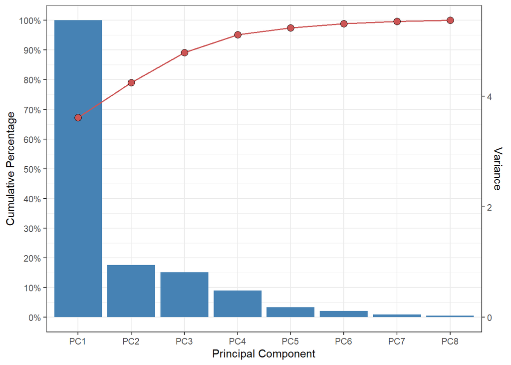

```
##
## $total_variance
##   PCA   variance contribution cumulative
## 1 PC1 5.37587230  0.671984038  0.6719840
## 2 PC2 0.94366326  0.117957908  0.7899419
## 3 PC3 0.81164365  0.101455456  0.8913974
## 4 PC4 0.48615594  0.060769492  0.9521669
## 5 PC5 0.18282657  0.022853321  0.9750202
## 6 PC6 0.11432193  0.014290241  0.9893105
## 7 PC7 0.05354682  0.006693352  0.9960038
## 8 PC8 0.03196954  0.003996192  1.0000000
```

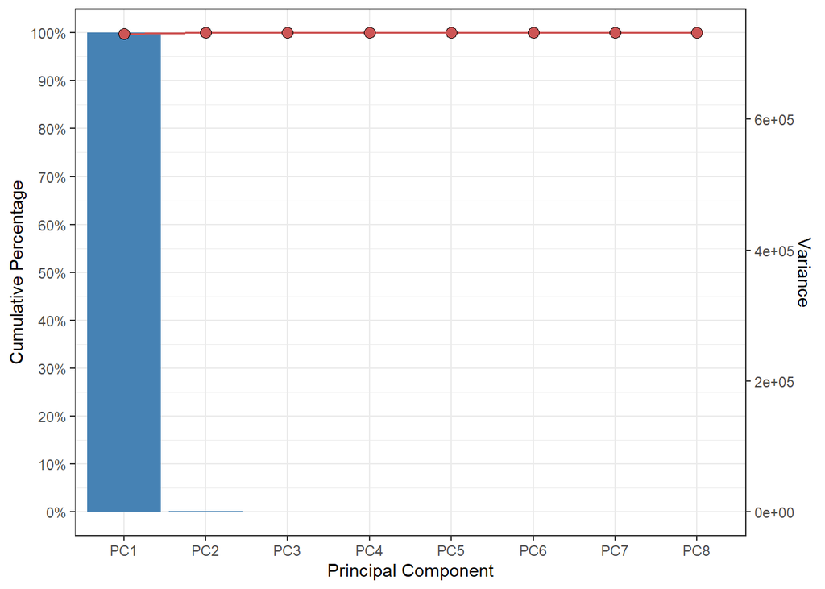

```r
results_cov$scree_plot
```

No, as we can see from the scree plot there are two different principal components and that’s why we need to choose the “isCorrMx”. In some cases, it may be necessary to standardize the variables to ensure that they are all on the same scale and have equal weighting in the analysis.

Q4. a.

```r
library(png)
library(dplyr)
library(scales)
library(reshape2)
path <- "C:/Users/simpl/OneDrive/桌面/111_下學期/資料分析方法/HW02/ORL Faces/ORL Faces"

data <- data.frame(matrix(nrow = 0, ncol = 2576),row.names = character())

for (i in 1:40) {
  for(j in 1:10){
    file <- file.path(path, paste0( i,"_",j,".png"))
    img <- readPNG(file)
    vec <- as.vector(img)
    data <- rbind(data, vec)
  }
}
names(data) <- paste0("Pixel", 1:2576)
results<-PCA(data,isCorrMX = TRUE)

component_count<-data.frame(tv=c("50%","60%","70%","80%","90%"),
                            count=0)
j<-1
z<-0.5
cumulative<-results$total_variance[,4]
for(i in 1:nrow(results$total_variance)){
  if(cumulative[i]>=z){
    component_count[j,2]<-i
    j<- j+1
    z<-z+0.1
  }
  if(j==6){
    break
  }
}
component_count
```

```
##    tv count
## 1 50%     6
## 2 60%     9
## 3 70%    17
## 4 80%    34
## 5 90%    79
```

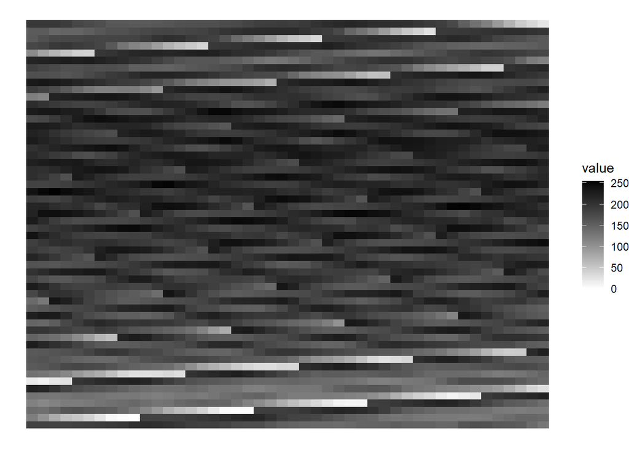

```r
firstPC<-results$loadingMatrix[,1]
pc1_rescaled<-rescale(firstPC,to=c(0,255))
pc1_matrix<-matrix(pc1_rescaled,nrow = 46,ncol=56)
df<-melt(pc1_matrix)
ggplot(df, aes(Var1, Var2)) +
  geom_raster(aes(fill=value))+
  scale_fill_gradient(low = "white", high = "black") +
  theme_void()
```